# Data Visualization

18 April, 2020

## Introduction

In this tutorial, we will play around with the [John Hopkins CSSE Covid-19 dataset](https://github.com/CSSEGISandData/COVID-19). We will learn basic data wrangling with `tidyverse` packages and data visualization with `ggplot2`. There is no pre-requisites for this tutorial, but having a basic knowledge about `R`, `RStudio`, and `Rmarkdown` would be useful.

## Some useful tips

- To render the `.Rmd` file into html document using RStudio IDE, press the *knit* button or press `Cmd + Shift + K` (MacOS) / `Ctrl + Shift + K` (Windows)
- `%>` [(forward pipe) operator](https://magrittr.tidyverse.org/) is used for passing forward the left-hand side values into expressions that appear on the right-hand side
- `!!` (bang bang) operator is a syntatic sugar for [unqouting code](https://tidyeval.tidyverse.org/sec-why-how.html#unquoting-code)
- Cheat sheets for quick reference:
  - [R Markdown](https://rstudio.com/wp-content/uploads/2015/02/rmarkdown-cheatsheet.pdf)
  - [Data wrangling with `dplyr` and `tidyr`](https://rstudio.com/wp-content/uploads/2015/02/data-wrangling-cheatsheet.pdf)
  - [`ggplot2`](https://rstudio.com/wp-content/uploads/2015/03/ggplot2-cheatsheet.pdf)

## Download and explore data

```r
data_raw <- read_csv("https://github.com/CSSEGISandData/COVID-19/raw/master/csse_covid_19_data/csse_covid_19_time_series/time_series_covid19_confirmed_global.csv")
head(data_raw)
```

```
## # A tibble: 6 x 91
##   `Province/State` `Country/Region`   Lat   Long `1/22/20` `1/23/20` `1/24/20`
##   <chr>            <chr>            <dbl>  <dbl>     <dbl>     <dbl>     <dbl>
## 1 <NA>             Afghanistan       33    65            0         0         0
## 2 <NA>             Albania           41.2  20.2          0         0         0
## 3 <NA>             Algeria           28.0   1.66         0         0         0
## 4 <NA>             Andorra           42.5   1.52         0         0         0
## 5 <NA>             Angola           -11.2  17.9          0         0         0
## 6 <NA>             Antigua and Bar…  17.1 -61.8          0         0         0
## # … with 84 more variables: `1/25/20` <dbl>, `1/26/20` <dbl>, `1/27/20` <dbl>,
## #   `1/28/20` <dbl>, `1/29/20` <dbl>, `1/30/20` <dbl>, `1/31/20` <dbl>,
## #   `2/1/20` <dbl>, `2/2/20` <dbl>, `2/3/20` <dbl>, `2/4/20` <dbl>,
## #   `2/5/20` <dbl>, `2/6/20` <dbl>, `2/7/20` <dbl>, `2/8/20` <dbl>,
## #   `2/9/20` <dbl>, `2/10/20` <dbl>, `2/11/20` <dbl>, `2/12/20` <dbl>,
## #   `2/13/20` <dbl>, `2/14/20` <dbl>, `2/15/20` <dbl>, `2/16/20` <dbl>,
## #   `2/17/20` <dbl>, `2/18/20` <dbl>, `2/19/20` <dbl>, `2/20/20` <dbl>,
## #   `2/21/20` <dbl>, `2/22/20` <dbl>, `2/23/20` <dbl>, `2/24/20` <dbl>,
## #   `2/25/20` <dbl>, `2/26/20` <dbl>, `2/27/20` <dbl>, `2/28/20` <dbl>,
## #   `2/29/20` <dbl>, `3/1/20` <dbl>, `3/2/20` <dbl>, `3/3/20` <dbl>,
## #   `3/4/20` <dbl>, `3/5/20` <dbl>, `3/6/20` <dbl>, `3/7/20` <dbl>,
## #   `3/8/20` <dbl>, `3/9/20` <dbl>, `3/10/20` <dbl>, `3/11/20` <dbl>,
## #   `3/12/20` <dbl>, `3/13/20` <dbl>, `3/14/20` <dbl>, `3/15/20` <dbl>,
## #   `3/16/20` <dbl>, `3/17/20` <dbl>, `3/18/20` <dbl>, `3/19/20` <dbl>,
## #   `3/20/20` <dbl>, `3/21/20` <dbl>, `3/22/20` <dbl>, `3/23/20` <dbl>,
## #   `3/24/20` <dbl>, `3/25/20` <dbl>, `3/26/20` <dbl>, `3/27/20` <dbl>,
## #   `3/28/20` <dbl>, `3/29/20` <dbl>, `3/30/20` <dbl>, `3/31/20` <dbl>,
## #   `4/1/20` <dbl>, `4/2/20` <dbl>, `4/3/20` <dbl>, `4/4/20` <dbl>,
## #   `4/5/20` <dbl>, `4/6/20` <dbl>, `4/7/20` <dbl>, `4/8/20` <dbl>,
## #   `4/9/20` <dbl>, `4/10/20` <dbl>, `4/11/20` <dbl>, `4/12/20` <dbl>,
## #   `4/13/20` <dbl>, `4/14/20` <dbl>, `4/15/20` <dbl>, `4/16/20` <dbl>,
## #   `4/17/20` <dbl>
```

## Data wrangling

Like any other data analysis task, first we need to clean and restructure our data.

Here we will use some function from `tidyverse` package to format our data.

*Note*: the `!!` (bang bang) operator is a syntatic sugar for [unqouting code](https://tidyeval.tidyverse.org/sec-why-how.html#unquoting-code)

### Renaming and aggregating data

To do analysis by country, first we need to aggregate data on country’s province / state

```r
date_start <- colnames(data_raw)[5]
date_end <- colnames(data_raw)[ncol(data_raw)]

# Rename column names
data <- data_raw %>%
  rename(country = `Country/Region`, area = `Province/State`) %>%
  # aggregate data per country
  group_by(country) %>%
  summarise_at(vars(!!date_start:!!date_end), sum)

head(data)
```

```
## # A tibble: 6 x 88
##   country `1/22/20` `1/23/20` `1/24/20` `1/25/20` `1/26/20` `1/27/20` `1/28/20`
##   <chr>       <dbl>     <dbl>     <dbl>     <dbl>     <dbl>     <dbl>     <dbl>
## 1 Afghan…         0         0         0         0         0         0         0
## 2 Albania         0         0         0         0         0         0         0
## 3 Algeria         0         0         0         0         0         0         0
## 4 Andorra         0         0         0         0         0         0         0
## 5 Angola          0         0         0         0         0         0         0
## 6 Antigu…         0         0         0         0         0         0         0
## # … with 80 more variables: `1/29/20` <dbl>, `1/30/20` <dbl>, `1/31/20` <dbl>,
## #   `2/1/20` <dbl>, `2/2/20` <dbl>, `2/3/20` <dbl>, `2/4/20` <dbl>,
## #   `2/5/20` <dbl>, `2/6/20` <dbl>, `2/7/20` <dbl>, `2/8/20` <dbl>,
## #   `2/9/20` <dbl>, `2/10/20` <dbl>, `2/11/20` <dbl>, `2/12/20` <dbl>,
## #   `2/13/20` <dbl>, `2/14/20` <dbl>, `2/15/20` <dbl>, `2/16/20` <dbl>,
## #   `2/17/20` <dbl>, `2/18/20` <dbl>, `2/19/20` <dbl>, `2/20/20` <dbl>,
## #   `2/21/20` <dbl>, `2/22/20` <dbl>, `2/23/20` <dbl>, `2/24/20` <dbl>,
## #   `2/25/20` <dbl>, `2/26/20` <dbl>, `2/27/20` <dbl>, `2/28/20` <dbl>,
## #   `2/29/20` <dbl>, `3/1/20` <dbl>, `3/2/20` <dbl>, `3/3/20` <dbl>,
## #   `3/4/20` <dbl>, `3/5/20` <dbl>, `3/6/20` <dbl>, `3/7/20` <dbl>,
## #   `3/8/20` <dbl>, `3/9/20` <dbl>, `3/10/20` <dbl>, `3/11/20` <dbl>,
## #   `3/12/20` <dbl>, `3/13/20` <dbl>, `3/14/20` <dbl>, `3/15/20` <dbl>,
## #   `3/16/20` <dbl>, `3/17/20` <dbl>, `3/18/20` <dbl>, `3/19/20` <dbl>,
## #   `3/20/20` <dbl>, `3/21/20` <dbl>, `3/22/20` <dbl>, `3/23/20` <dbl>,
## #   `3/24/20` <dbl>, `3/25/20` <dbl>, `3/26/20` <dbl>, `3/27/20` <dbl>,
## #   `3/28/20` <dbl>, `3/29/20` <dbl>, `3/30/20` <dbl>, `3/31/20` <dbl>,
## #   `4/1/20` <dbl>, `4/2/20` <dbl>, `4/3/20` <dbl>, `4/4/20` <dbl>,
## #   `4/5/20` <dbl>, `4/6/20` <dbl>, `4/7/20` <dbl>, `4/8/20` <dbl>,
## #   `4/9/20` <dbl>, `4/10/20` <dbl>, `4/11/20` <dbl>, `4/12/20` <dbl>,
## #   `4/13/20` <dbl>, `4/14/20` <dbl>, `4/15/20` <dbl>, `4/16/20` <dbl>,
## #   `4/17/20` <dbl>
```

### Pick countries to highlight

Next we want to highlight some countries with the most number of cases in the last day, and perhaps add some additional countries

```r
# arrange country by total number of cases in the last day
data <- data %>%
  arrange(desc(!!as.symbol(date_end)))

# Find top 10 countries with most cases
top_countries <- data$country[1:10]

# Optional (add additional countries)
top_countries <-
  c(top_countries, "Korea, South", "Singapore", "Brazil", "South Africa")

# Subset data to include only selected countries
data_top_countries <- data %>%
  filter(country %in% top_countries)
```

### Transposing data

`ggplot2` implements [*A layered grammar of graphics*](https://vita.had.co.nz/papers/layered-grammar.html) framework for data visualization which requires data values to be mapped onto *aesthetics* (quantifiable features of the resulting graphic).

To do this, we want to transpose the date variables in our data into a single column so that we can represent our data in an `x,y` coordinate, with `x` being the time and `y` being the number of cases.

```r
data_long <- data_top_countries %>%
  pivot_longer(cols = !!date_start:!!date_end,
               names_to = "date",
               values_to = "N") %>%
  # reformat date
  mutate(date = mdy(date))

head(data_long)
```

```
## # A tibble: 6 x 3
##   country date           N
##   <chr>   <date>     <dbl>
## 1 US      2020-01-22     1
## 2 US      2020-01-23     1
## 3 US      2020-01-24     2
## 4 US      2020-01-25     2
## 5 US      2020-01-26     5
## 6 US      2020-01-27     5
```

### Count day after first N case

As countries may be at different phases of the outbreak at a certain date, we want to convert the date into *day after first N reported cases* so our results are more comparable.

```r
min_N <- 100

data_plot <- data_long %>%
  filter(N >= min_N) %>%
  # group by country
  group_by(country) %>%
  mutate(day = seq_along(date))

head(data_plot)
```

```
## # A tibble: 6 x 4
## # Groups:   country [1]
##   country date           N   day
##   <chr>   <date>     <dbl> <int>
## 1 US      2020-03-03   118     1
## 2 US      2020-03-04   149     2
## 3 US      2020-03-05   217     3
## 4 US      2020-03-06   262     4
## 5 US      2020-03-07   402     5
## 6 US      2020-03-08   518     6
```

## Plotting

Now that we have a plan, it’s time to get back to work!

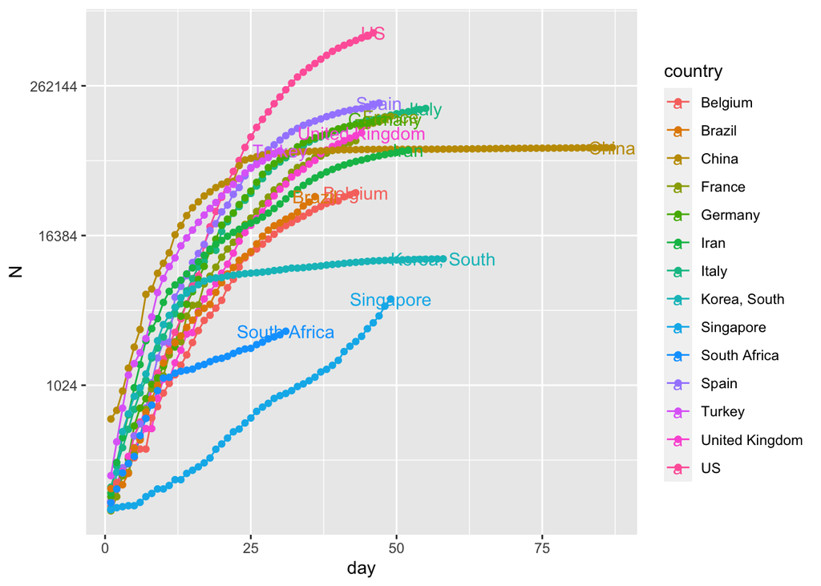

```r
ggplot(
  data = data_plot,
  mapping = aes(
    x = day,
    y = N,
    color = country,
    label = country,
    group = country)
  ) +
  # create line chart
  geom_line() +
  # create scatter plot
  geom_point() +
  # add country label
  geom_text(data = . %>% group_by(country) %>% filter(day == max(day))) +
  # tranform y-axis to log scale
  scale_y_continuous(trans = "log2")
```

### Decorating the plot

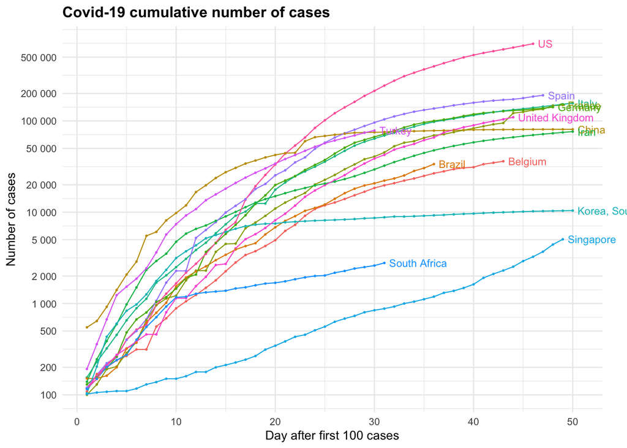

```r
## Take 2
ggplot(
  # cut until day 50
  data = data_plot %>% filter(day <= 50),
  mapping = aes(
    x = day,
    y = N,
    color = country,
    label = country,
    group = country)
  ) +
  # make the line and point smaller
  geom_line(size = 0.4, show.legend = F) +
  geom_point(size = 0.3) +
  # add country label
  geom_text(data = . %>% group_by(country) %>% filter(day == max(day)),
            # adjust label position
            hjust = 0, nudge_x = 0.5,
            # make smaller text
            size = 3
            ) +
  # Y-axis
  scale_y_continuous(
    trans = "log2",
    # adjust breaks
    breaks = c(c(1,2,5)%o% 10^(0:5)),
    # format breaks
    labels = scales::number_format(accuracy = 1)
    ) +
  # X-Axis
  scale_x_continuous(
    breaks = seq(0,100,10)
  ) +
  # Change X-Axis, Y-Axis, Title label
  labs(
    title = "Covid-19 cumulative number of cases",
    y = "Number of cases",
    x = paste("Day after first", min_N, "cases")
  ) +
  # Turn off clipping
  coord_cartesian(clip = "off") +
  # change overall looks
  theme_minimal(base_size = 10) +
  # change background
  theme(
    # hide legend
    legend.position = "none",
    # adjust plot margin
    plot.margin = margin(t=5, r=20, b= 5, l =5),
    # adjust title
    plot.title = element_text(face = "bold", size = 12)
  )
```

### Extra touch

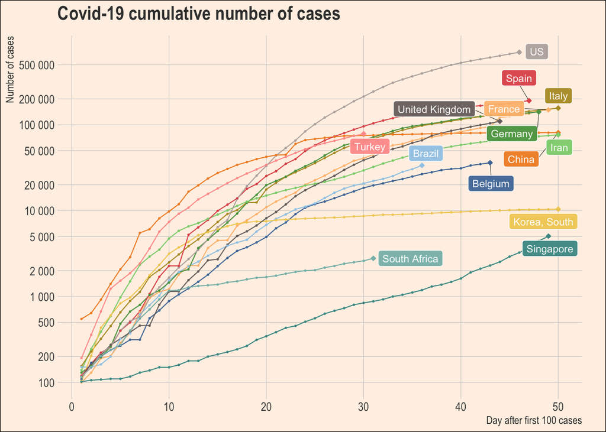

```r
library(hrbrthemes)
library(ggrepel)
library(ggthemes)

ggplot(
  # cut until day 50
  data = data_plot %>% filter(day <= 50),
  mapping = aes(
    x = day,
    y = N,
    color = country,
    label = country,
    group = country,
    fill = country)
  ) +
  # make the line and point smaller
  geom_line(size = 0.4, show.legend = F) +
  geom_point(size = 0.3) +
  # add country label
  geom_label_repel(
    data = . %>% group_by(country) %>% filter(day == max(day)),
    # adjust label position
    hjust = 0, nudge_x = 0.5,
    colour = "white", alpha = 0.95,
    segment.size = 0.2, segment.color = "gray20",
    # make smaller text
    size = 3 ) +
  # highlight last day
  geom_point(
    data = . %>% filter(day == max(day)),
    shape = 23, size = 1.1) +
  # change colour
  scale_colour_tableau(palette = "Tableau 20") +
  scale_fill_tableau(palette = "Tableau 20") +
  # Y-axis
  scale_y_continuous(
    trans = "log2",
    # adjust breaks
    breaks = c(c(1,2,5)%o% 10^(0:5)),
    # format breaks
    labels = scales::number_format(accuracy = 1),
    ) +
  # X-Axis
  scale_x_continuous(
    breaks = seq(0,100,10)
  ) +
  # Change X-Axis, Y-Axis, Title label
  labs(
    title = "Covid-19 cumulative number of cases",
    y = "Number of cases",
    x = paste("Day after first", min_N, "cases")
  ) +
  # Turn off clipping
  coord_cartesian(clip = "off") +
  # change overall looks
  theme_ipsum(base_size = 10) +
  # change background
  theme(
    # hide legend
    legend.position = "none",
    # adjust plot margin
    plot.margin = margin(t=5, r=20, b= 5, l =5),
    # remove minor grid
    panel.grid.minor = element_blank(),
    # adjust title
    text = element_text(color = "grey23"),
    plot.title = element_text(face = "bold", size = 16),
    axis.title = element_text(face = "bold"),
    plot.background = element_rect(fill = "#fff1e5")
  )
```

### Saving plots

```r
# by default ggsave will save the last generated plot
ggsave("my_beautiful_plot.png",
       width = 8,
       height = 5)
```